# The Purpose of Research

GE2021 Research Technology, Fall 2026

Chad (Chungil Chae)

cchae@kean.edu

Tue, 15 September 2026

# Learning Objectives

1. Describe the purpose of scientific research
2. Describe two theories of knowledge: falsifiability and the scientific revolution
3. Compare and contrast qualitative, quantitative, and mixed methods
4. Explain the importance of ethics and objectivity in research Pajo (2022)

## What is reserach?

[video not shown]

# Scientific Research and Its Purpose

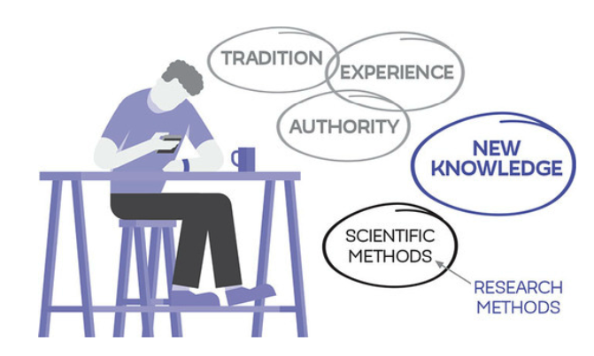

## Not a Scientific Knowledge

- **Traditional Knowledge**: a form of knowledge inherited from the culture one grew up in
- **Authority**: a form of knowledge believed to be true because its source is authoritative, such as parents or teachers.
- **Experiential knowledge**: a form of knowledge gained through experiences

## Scientific Knowledge

- **Scientific knowledge**: a form of knowledge based on studies conducted by researchers; knowledge that can be trusted.
- New scientific knowledge is produced by systematic research
- Reality and knowledge are two different things
- Research is generated by following sets of rules, embodying skills, and following a framework to analyze results.

# Theories of Knowledge

Karl Popper’s Falsifiability

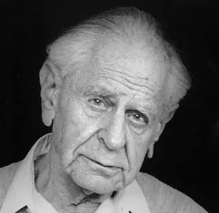

https://plato.stanford.edu/entries/popper/

Thomas Kuhn’s Structure of Scientific Revolution

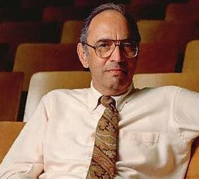

https://plato.stanford.edu/entries/thomas-kuhn/

## Karl Popper’s Falsifiability

- Systematic attempts to prove things wrong advance scientific knowledge
- Empirical evidence: acquiring data or information by systematically observing people or events, i.e. practical experience.
- Falsified: proven an established theory wrong.
- PS1 is a problem situation or issue
- To explain this problem, there are a number of tentative theories, or TT1.
- If we try to falsify these tentative theories by error of elimination,
- EE1, we find that most of our tentative theories are incorrect and there is a new explanation for the first problem we started on.
- Through this natural selection process, we build new knowledge and end up with a new problem situation, PS2.

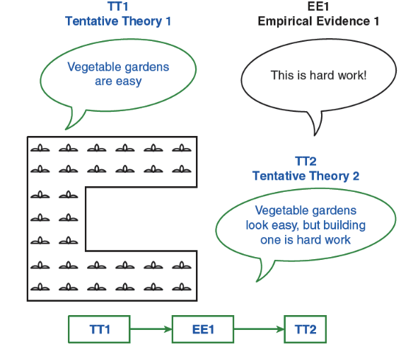

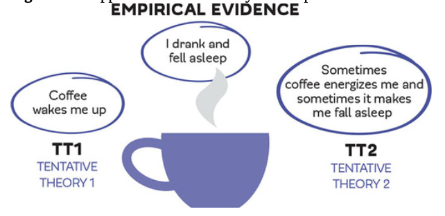

> PS1 -> TT1 -> EE1 -> PS2

## Thomas Kuhn’s Structure of Scientific Revolution

- **Normal science**: general rules, laws and paradigms accepted as truths; does not aim to explore new ideas or build on scientific knowledge, experiment, or risk.
- **Paradigm**: an unchangeable pattern used over and over again; widely accepted by the scientific community.
- **Anomalies**: things that do not fit into the paradigms of normal science; happens once or twice and does not fit into commonly accepted patterns.
- **Crisis**: the accumulation of many anomalies against an accepted truth of normal science; encountered when normal science does not fit with reality anymore.
- **Revolution**: after a crisis, the revolution replaces the old paradigm with a new paradigm.
- **Paradigm shift**: when the widely accepted paradigm encounters many anomalies, leading to crisis, then revolution, and settles into a new paradigm, which becomes accepted and the new normal science.

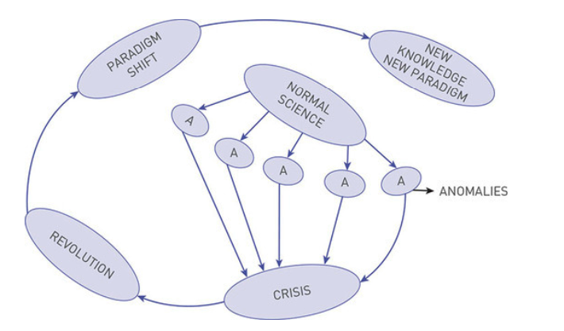

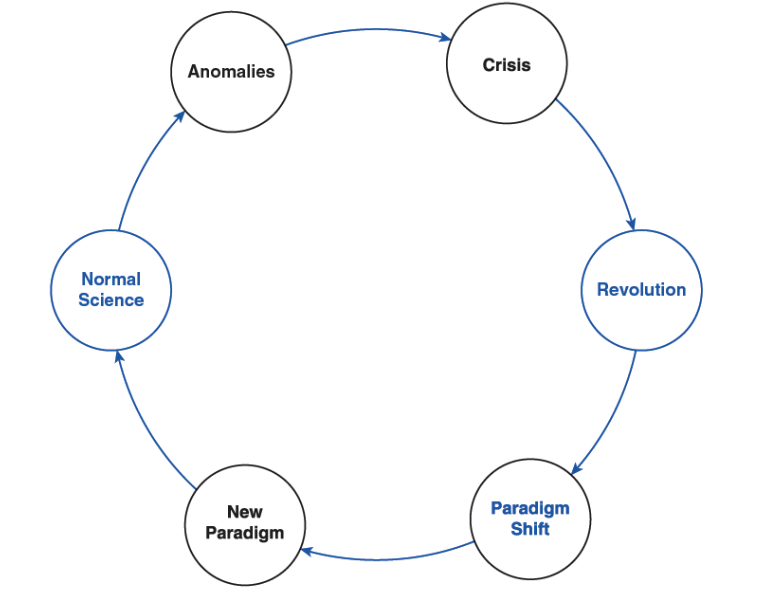

# III. A Quick Look at Qualitative, Quantitative, and Mixed Methods

## Qualitative Research

- Qualitative research aims at gaining insight and depth; not just simple facts, but insights, emotions, perspectives, and so on about the topic of research

**Inductive reasoning**

Inductive reasoning: begins with specific observations and moves to a broader understanding of a topic or problem; often leads to creating new theories of science; allows researchers to become immersed in their study without preconceived notions or assumptions.

## Quantitative Research

- Quantitative Research requires a good grasp of the topic of study and research conducted in that topic before data collection; the design of study is essential and their work is based on the systematic calculation of data

**Deductive reasoning**

Deductive reasoning begins with a broad theory that can lead to a specific idea or concept that is ready to be tested; data collection is straightforward with no digressions.

# Ethical Research

## Ethics and Research Ethics

- **Ethics**: the group of morals and values that govern behaviors and decisions
- **Research ethics**: research ethics use rules and regulations concerned with protecting the rights of people who participate in research studies.

## Ethical Rules

- Informed consent provides participants with information about the study, particularly about any risks involved.
- Confidentiality is the promise not to disclose identifiable information about the participant to any third party.
- It is unethical to coerce people into taking part in a study
- Conflict of interest is also a concern; it refers to the possibility that the study may be part of an outside agenda.

## A Violation of Ethics

> The Tuskegee syphilis study is an infamous case of ethics violation in research.
- It started with…
  - Between 1932 and 1972, the United States Public Health Service and the Tuskegee Institute conducted a study on the effects of syphilis on the human body.
- What happened?
  - The researchers recruited 600 African American men to participate, but did not disclose the focus of their study to their participants, who were simply told they were being treated for “bad blood.”
  - Many believed they were receiving free health services from the government.
  - Two-thirds of the participating men had syphilis, and despite the fact that penicillin was validated as an effective treatment in 1942, not one of the men in the Tuskegee study received treatment.
  - This continued for an additional 30 years, and was finally revealed through a leak to the newspapers in the early 1970s.
- What impact?
  - Only 74 participants survived. Around 40 of their wives were also infected and 19 children were born with syphilis (U.S. Public Health Service Syphilis Study at Tuskegee, 2013).
  - The tragedy of the Tuskegee study is measured not only in numbers directly affected, but in the lasting resentment it caused within the African American community.

## Researchers’ Biases

- **Objectivity**: perceiving something from different angles without personal preferences or judgements.
- **Subjective thinking**: based on personal emotions, experiences, and prejudices.
- **Selective observation**: a common type of bias, when one is focused on a specific occurrence or group of people instead of including an entire sample of the observation; that is, focuses on what interests the researcher and failing to notice things that may contradict their theory.
- **Overconfidence bias**: when a researcher feels overconfident in their own abilities and does not consider additional details or aspect that could need more attention.
- **Overgeneralization**: using a small number of cases to draw conclusions about the entire population.

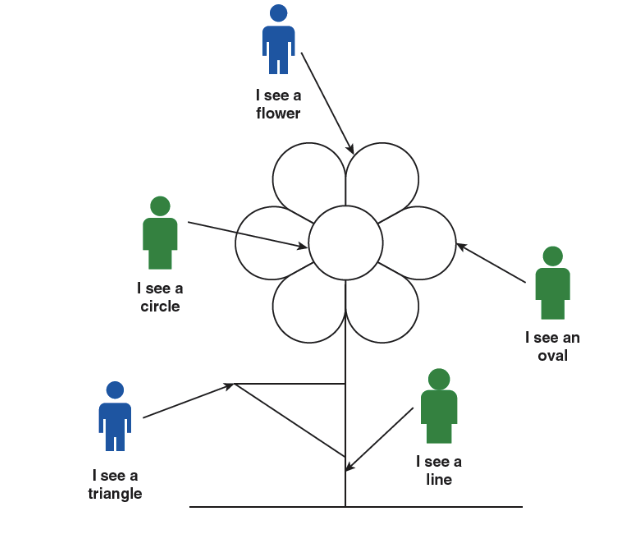

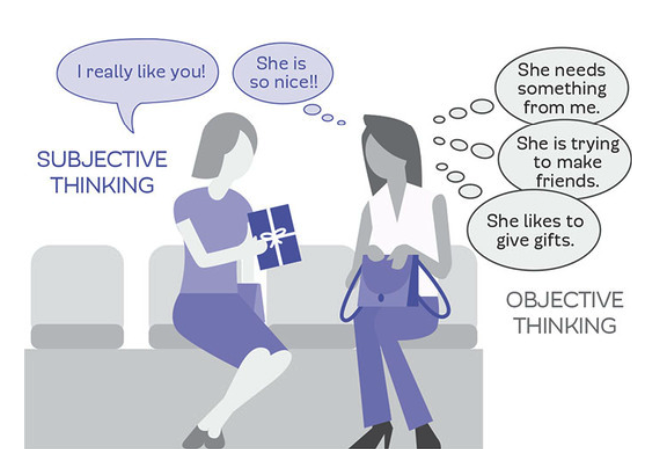